# R Notebook

```r
if (FALSE) {
  installPackagesNeeded()
}
```

## Processo

Um paciente que está em lista de espera para ser operado:

1. Entra em contacto com o serviço de cirurgia, vários dias antes da sua operação,
- Através de uma chamada telefónica ou
- Através do envio de uma mensagem escrita numa app.
2. Os serviços administrativos atendem as chamadas ou lêem a mensagem via app e, mediante
- a informação presente no sistema dada pelo médico assistente e
- a informação fornecida pelo paciente, o administrativo decide se agenda
- uma consulta presencial antes da cirurgia, ou
- uma consulta telefónica, ou
- não há necessidade de qualquer consulta.

Contudo, este procedimento necessita de melhorias. O objectivo deste estudo é optimizar a gestão dos contactos (tempo total do processo e total de chamadas perdidas)

## Situação atual

1. Apenas 2 administrativos no serviço, ambos começam às 8h e acabam às 18h (10h de trabalho) de cada dia útil.
2. O tempo entre chegadas tem exp(1/40) (pq media de 40/h)
3. Tipo de contacto:
- prob de telefone = 0.85
- prob de app = 0.15
4. Tipo de consulta:
- 0.3 não é agendado consulta,
- 0.6 consula por telefone,
- 0.1 presencial
5. Tempo de
- Conversa antes da decisao é norm(4,1^2)
- Tomada de decisao do adminstrativo é norm(1,0.25^2)
- Tempo de agendamento SE NECESSÁRIO é norm(1,0.25^2)
6. 5o telefone desliga apos 5 minutos de espera (e fica chamada perdida)

```r
library(simmer)
library(simmer.bricks)
library(simmer.plot)
conflicts_prefer(simmer::rollback)
```

```
[conflicted] Will prefer simmer::rollback over any other package.
```

```r
conflicts_prefer(simmer::now)
```

```
[conflicted] Will prefer simmer::now over any other package.
```

```r
conflicts_prefer(dplyr::select)
```

```
[conflicted] Will prefer dplyr::select over any other package.
```

```r
# this will be substituted below and literally just is here because simmer doesn't know how to implement pipes and I hate it here
env <- simmer("hospital")
```

Resources: Server: O hospital com 2 administradores Queue: Fila de espera com prioridade de clients em chamada Não há vantgem em escolher a app quando há chamada de espera Manager: vai atribuir o tipo de consulta (e Vai alterar o tipo de cliente se ele for rejeitado na chamada?) Gerador: vai gerir novos arrivals (exp(1/40)) arrival: cada paciente (que leva uma trajectory) trajectory: a receita de cada arrival

```r
# atributes need to be numeric
tipo_de_consulta.PRESENCIAL <- 1
tipo_de_consulta.TELEFONICA <- 2
tipo_de_consulta.NAO_AGENDADA <- 3
tipos_de_consulta <- c(tipo_de_consulta.PRESENCIAL, tipo_de_consulta.TELEFONICA, tipo_de_consulta.NAO_AGENDADA)
tipos_de_consulta.probs <- c(0.1, 0.6, 0.3)

tipo_de_contacto.TELEFONE <- 1
tipo_de_contacto.APP <- 2
tipos_de_contacto <- c(tipo_de_contacto.TELEFONE, tipo_de_contacto.APP)
tipos_de_contacto.probs <- c(0.85, 0.15)

tempo_atendido <- function() {
  mean_time_triagem <- rnorm(1, mean = 4, sd = 1)
  mean_time_decision <- rnorm(1, mean = 1, sd = 0.25)
  time_to_timeout <- mean_time_triagem + mean_time_decision

  if (get_attribute(env, "tipo_de_consulta") != tipo_de_consulta.NAO_AGENDADA) {
    time_to_timeout <- time_to_timeout + rnorm(1, mean = 1, sd = 0.25)
  }

  return(time_to_timeout)
}

intime <- function() {
  now(env)%% 24*60 -> n
  return(8*60 < n & n < 18*60)
}
```

```r
pessoa <- trajectory("pessoa") %>%
  # set_attribute("times_phone_rejected", 0) %>%
  # set_attribute("phone_rejected", 0) %>%
  set_attribute("tipo_de_consulta", \() sample(tipos_de_consulta, 1, prob = tipos_de_consulta.probs)) %>%
  set_attribute("tipo_de_contacto", \() sample(tipos_de_contacto, 1, prob = tipos_de_contacto.probs), tag = "contacto") %>%
  set_prioritization(\() if (get_attribute(env, "tipo_de_contacto") == tipo_de_contacto.TELEFONE) c(1, -1, FALSE) else c(0 , -1, FALSE)) %>% # PRIORITY, DROP PRIORITY, RESTART
  # log_(\() paste("Vou pra fila agora, estou a usar", ifelse(get_attribute(env, "tipo_de_contacto") == tipo_de_contacto.TELEFONE, "o telefone", "a app"))) %>%
  renege_in(\() ifelse(get_attribute(env, "tipo_de_contacto") == tipo_de_contacto.TELEFONE, 5, Inf), out =
              trajectory() %>% set_attribute("phone_rejected", 1)
              # O botas não gostou
              # trajectory("pessoa_try_again") %>%
              # set_attribute("times_phone_rejected", \() get_attribute(env, "times_phone_rejected") + 1) %>%
              # # leave if out of schedule
              # leave(\() {ifelse(intime(), 0, 1)}) %>%
              # # log_(\() "Nao fui atendido, vou voltar pra fila") %>%
              # rollback(target="contacto", times = 1) # não funciona, mudar pra numero?
            ) %>%
  seize("administrador", 1) %>%
  renege_abort() %>%
  # log_(\() paste("Before timeout")) %>%
  set_attribute("atendido", 1) %>%
  timeout(tempo_atendido) %>%
  # log_(\() "After timeout") %>%
  release("administrador", 1)
  # log_(\() "Leaving")

pessoa
```

```
trajectory: pessoa, 10 activities
{ Activity: SetAttribute | keys: [tipo_de_consulta], values: function(), global: 0, mod: N, init: 0 }
{ Activity: SetAttribute | [contacto] keys: [tipo_de_contacto], values: function(), global: 0, mod: N, init: 0 }
{ Activity: SetPrior     | values: function(), mod: N }
{ Activity: RenegeIn     | t: function(), keep_seized: 0 }
  Fork 1, stop,  trajectory: anonymous, 1 activities
  { Activity: SetAttribute | keys: [phone_rejected], values: [1], global: 0, mod: N, init: 0 }
{ Activity: Seize        | resource: administrador, amount: 1 }
{ Activity: RenegeAbort  |  }
{ Activity: SetAttribute | keys: [atendido], values: [1], global: 0, mod: N, init: 0 }
{ Activity: Timeout      | delay: function() }
{ Activity: Release      | resource: administrador, amount: 1 }
```

```r
set.seed(1)
# 50 replicas
envs <- lapply(1:50, function(i) {
  env <<- simmer("hospital")
  env %>%
    add_generator("pessoa", pessoa, from_to(8*60, 18*60, \() rexp(1, 40/60), every = 24*60, arrive = F), mon = 2) %>%
    add_resource("administrador", schedule(c(8*60, 18*60), c(2, 0), period = 24*60)) %>%
    run(24*60*5)
})

envs %>% simmer.plot::get_mon_arrivals(ongoing = T) -> arrivals
envs %>% simmer.plot::get_mon_attributes() -> attributes
envs %>% simmer.plot::get_mon_resources() -> resources
```

```r
arrivals %>%
  filter(start_time != -1) %>% # n sei pq e q isto acontece
  arrange(start_time) %>%
  select(-activity_time) %>%
  mutate(
    day = ceiling(start_time/(24*60)),
    start_time_day = start_time %% (24*60) %>% seconds_to_period(),
    end_time_day = end_time %% (24*60) %>% seconds_to_period(),
    # replication = replication %>% as_factor(),
  ) -> arrivals.df1
arrivals.df1 %>% filter(replication == 1) %>% mutate(start_time_day = start_time_day %>% round(3), end_time_day = end_time_day %>% round(3))
```

| name | start_time | end_time | finished | replication | day | start_time_day | end_time_day |
| --- | --- | --- | --- | --- | --- | --- | --- |
| pessoa0 | 481.1328 | 488.6053 | TRUE | 1 | 1 | 8M 1.133S | 8M 8.605S |
| pessoa1 | 481.3425 | 486.9379 | TRUE | 1 | 1 | 8M 1.342S | 8M 6.938S |
| pessoa2 | 482.1520 | 493.7316 | TRUE | 1 | 1 | 8M 2.152S | 8M 13.732S |
| pessoa3 | 484.3620 | 492.3664 | TRUE | 1 | 1 | 8M 4.362S | 8M 12.366S |
| pessoa4 | 490.9979 | 497.9037 | TRUE | 1 | 1 | 8M 10.998S | 8M 17.904S |
| pessoa5 | 491.4391 | 498.3602 | TRUE | 1 | 1 | 8M 11.439S | 8M 18.36S |
| pessoa6 | 491.5282 | 496.5282 | TRUE | 1 | 1 | 8M 11.528S | 8M 16.528S |
| pessoa7 | 493.2882 | 505.1962 | TRUE | 1 | 1 | 8M 13.288S | 8M 25.196S |
| pessoa8 | 493.7742 | 505.9681 | TRUE | 1 | 1 | 8M 13.774S | 8M 25.968S |
| pessoa9 | 494.8620 | 499.8620 | TRUE | 1 | 1 | 8M 14.862S | 8M 19.862S |

[output cut: 990 more lines]

```r
# turn what's above into a function so it can be done for 2a and 2b
# get_arrivals <- function(mon_attributes) {
#   mon_attributes %>%
#     filter(start_time != -1) %>% # n sei pq e q isto acontece
#     arrange(start_time) %>%
#     select(-activity_time) %>%
#     mutate(
#       day = ceiling(start_time/(24*60)),
#       start_time_day = start_time %% (24*60) %>% seconds_to_period(),
#       end_time_day = end_time %% (24*60) %>% seconds_to_period(),
#       # replication = replication %>% as_factor(),
#     )
# }
#
# pprint_arrivals <- function (arrivals.df1) {
#   arrivals.df1 %>% filter(replication == 1) %>% mutate(start_time_day = start_time_day %>% round(3), end_time_day = # end_time_day %>% round(3))
# }
```

```r
# analise de eficiencia
# numero de chamadas perdidas
# add day to atributes from arrivals.df1
attributes %>%
  left_join(arrivals.df1 %>% select(name, replication, day, start_time, end_time, end_time_day), by = c("name", "replication")) %>%
  rename(atribute_time = time, pessoa_start_time = start_time, pessoa_end_time = end_time) %>%
  select(atribute_time, name, key, value, replication, day, pessoa_start_time, pessoa_end_time) -> attributes.df1
attributes.df1
```

| atribute_time | name | key | value | replication | day | pessoa_start_time | pessoa_end_time |
| --- | --- | --- | --- | --- | --- | --- | --- |
| 481.1328 | pessoa0 | tipo_de_consulta | 2 | 1 | 1 | 481.1328 | 488.6053 |
| 481.1328 | pessoa0 | tipo_de_contacto | 1 | 1 | 1 | 481.1328 | 488.6053 |
| 481.1328 | pessoa0 | atendido | 1 | 1 | 1 | 481.1328 | 488.6053 |
| 481.3425 | pessoa1 | tipo_de_consulta | 3 | 1 | 1 | 481.3425 | 486.9379 |
| 481.3425 | pessoa1 | tipo_de_contacto | 1 | 1 | 1 | 481.3425 | 486.9379 |
| 481.3425 | pessoa1 | atendido | 1 | 1 | 1 | 481.3425 | 486.9379 |
| 482.1520 | pessoa2 | tipo_de_consulta | 3 | 1 | 1 | 482.1520 | 493.7316 |
| 482.1520 | pessoa2 | tipo_de_contacto | 2 | 1 | 1 | 482.1520 | 493.7316 |
| 484.3620 | pessoa3 | tipo_de_consulta | 2 | 1 | 1 | 484.3620 | 492.3664 |
| 484.3620 | pessoa3 | tipo_de_contacto | 1 | 1 | 1 | 484.3620 | 492.3664 |

[output cut: 990 more lines]

```r
# pessoas e os seus tipos de chamada
attributes.df1 %>%
  filter(key == "tipo_de_contacto") %>%
  select(name, replication, value) %>%
  mutate(value = ifelse(value == tipo_de_contacto.TELEFONE, "telefone", "app")) %>%
  rename(contacto = value) -> contactos.df1
```

```r
# percentagem de chamadas perdidas
attributes.df1 %>%
  filter(key == "tipo_de_contacto", value == tipo_de_contacto.TELEFONE) %>%
  left_join(attributes.df1 %>% filter(key == "phone_rejected") %>% mutate(gave_up = key) %>% select(name, replication, gave_up), join_by("name", "replication")) %>%
  mutate(gave_up = if_else(gave_up %>% is.na, T, F), replication = replication %>% as_factor) %>%
  select(name, replication, pessoa_end_time, gave_up) -> phone_calls
phone_calls
```

| name | replication | pessoa_end_time | gave_up |
| --- | --- | --- | --- |
| pessoa0 | 1 | 488.6053 | TRUE |
| pessoa1 | 1 | 486.9379 | TRUE |
| pessoa3 | 1 | 492.3664 | TRUE |
| pessoa4 | 1 | 497.9037 | TRUE |
| pessoa5 | 1 | 498.3602 | TRUE |
| pessoa6 | 1 | 496.5282 | FALSE |
| pessoa7 | 1 | 505.1962 | TRUE |
| pessoa8 | 1 | 505.9681 | TRUE |
| pessoa9 | 1 | 499.8620 | FALSE |
| pessoa10 | 1 | 503.5031 | FALSE |

[output cut: 990 more lines]

```r
# phone_calls rate per replication
phone_calls %>%
  group_by(replication) %>%
  summarise(phone_calls = n(), gave_up = sum(gave_up)) %>%
  mutate(phone_calls_per_hour = phone_calls/10, gave_up_rate = gave_up/phone_calls) %>%
  arrange(desc(gave_up_rate)) -> phone_calls_rate
phone_calls_rate
```

| replication | phone_calls | gave_up | phone_calls_per_hour | gave_up_rate |
| --- | --- | --- | --- | --- |
| 30 | 1641 | 957 | 164.1 | 0.5831810 |
| 2 | 1639 | 954 | 163.9 | 0.5820622 |
| 26 | 1612 | 933 | 161.2 | 0.5787841 |
| 6 | 1649 | 946 | 164.9 | 0.5736810 |
| 1 | 1612 | 924 | 161.2 | 0.5732010 |
| 33 | 1637 | 938 | 163.7 | 0.5729994 |
| 49 | 1679 | 954 | 167.9 | 0.5681954 |
| 40 | 1671 | 948 | 167.1 | 0.5673250 |
| 21 | 1701 | 962 | 170.1 | 0.5655497 |
| 9 | 1714 | 967 | 171.4 | 0.5641774 |

[output cut: 40 more lines]

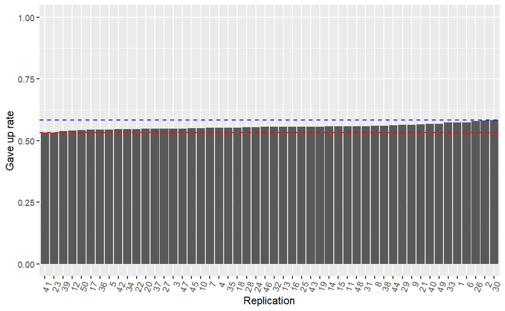

```r
phone_calls_rate %>%
  ggplot(aes(x = reorder(replication, gave_up_rate), y = gave_up_rate)) +
  geom_col() +
  ylim(0, 1) +
  theme(axis.text.x = element_text(angle = 70, hjust = 1)) +
  geom_hline(aes(yintercept = min(gave_up_rate)), linetype = "dashed", color = "red") +
  geom_hline(aes(yintercept = max(gave_up_rate)), linetype = "dashed", color = "blue") +
  xlab("Replication") +
  ylab("Gave up rate")

ggsave("gave_up_rate.svg")
```

```r
phone_calls_rate %>%
  summarise(
    min = min(phone_calls_per_hour),
    mean = mean(phone_calls_per_hour),
    max = max(phone_calls_per_hour)
    )
```

| min | mean | max |
| --- | --- | --- |
| 161.2 | 170.416 | 179.9 |

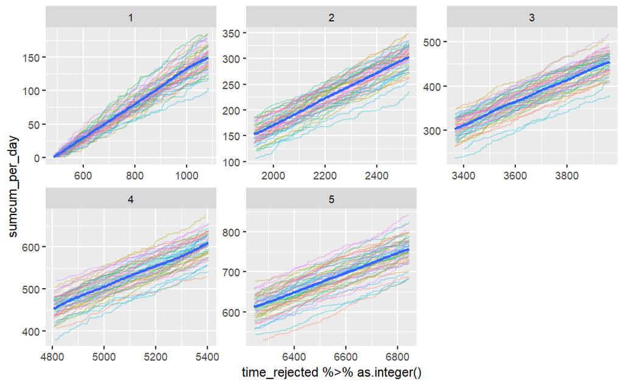

```r
# evolucao ao longo do dia DO QUE?
attributes.df1 %>%
  filter(key == "phone_rejected") %>%
  mutate(day = day %>% as_factor(), replication = replication %>% as_factor) %>%
  group_by(replication) %>%
  reframe(time_rejected = pessoa_end_time, sumcum_per_day = cumsum(value), day = day) %>%
  ggplot(aes(x = time_rejected %>% as.integer(), y = sumcum_per_day)) +
  geom_line(aes(color = replication), alpha = 0.3) +
  geom_smooth() +
  facet_wrap(vars(day), scale = "free") +
  theme(legend.position = "none")
```

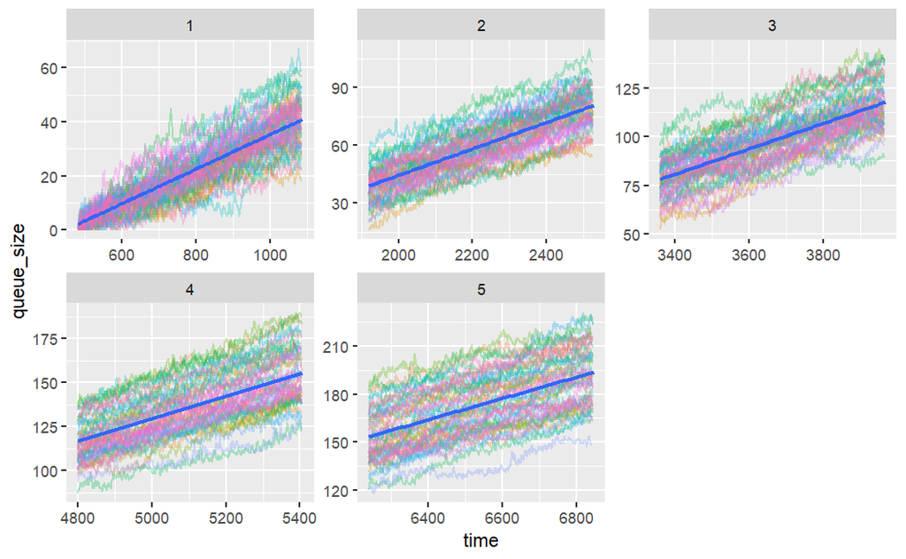

```r
# get queue size histogram
resources %>%
  mutate(day = ceiling(time/(24*60))) %>%
  group_by(replication) %>%
  reframe(day = day %>% as_factor(), time = time, queue_size = queue) %>%
  mutate(replication = replication %>% as_factor()) %>%
  ggplot(aes(x = time, y = queue_size)) +
  geom_step(aes(color = replication), alpha = 0.3) +
  geom_smooth(method="lm") +
  facet_wrap(vars(day), scale = "free") +
  theme(legend.position = "none")
```

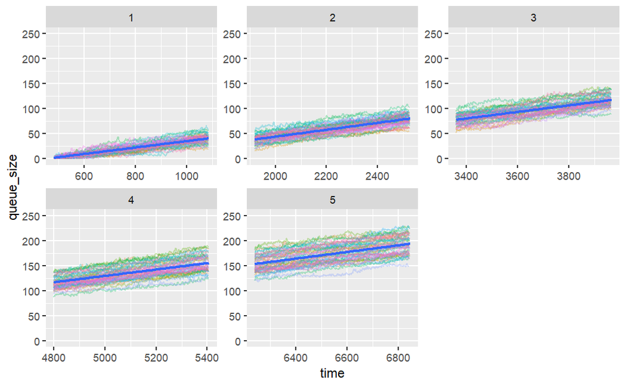

```r
resources %>%
  mutate(day = ceiling(time/(24*60))) %>%
  group_by(replication) %>%
  reframe(day = day %>% as_factor(), time = time, queue_size = queue) %>%
  mutate(replication = replication %>% as_factor()) %>%
  ggplot(aes(x = time, y = queue_size)) +
  geom_step(aes(color = replication), alpha = 0.3) +
  geom_smooth(method="lm") +
  facet_wrap(vars(day), scale = "free") +
  theme(legend.position = "none") +
  ylim(0,250)
```

```r
NA
NA
```

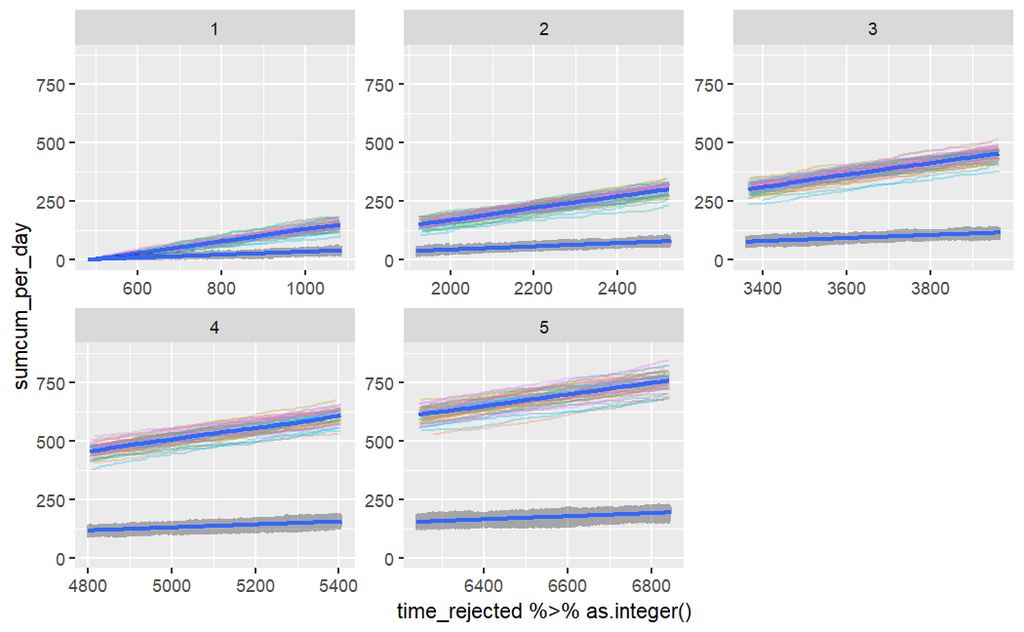

```r
# join these 2 plots
attributes.df1 %>%
  filter(key == "phone_rejected") %>%
  mutate(day = day %>% as_factor(), replication = replication %>% as_factor) %>%
  group_by(replication) %>%
  reframe(time_rejected = pessoa_end_time, sumcum_per_day = cumsum(value), day = day) %>%
  ggplot(aes(x = time_rejected %>% as.integer(), y = sumcum_per_day)) +
  geom_line(aes(color = replication), alpha = 0.3) +
  geom_smooth() +
  facet_wrap(vars(day), scale = "free") +
  theme(legend.position = "none") +
  geom_step(data = resources %>%
              mutate(day = ceiling(time/(24*60))) %>%
              group_by(replication) %>%
              reframe(day = day %>% as_factor(), time = time, queue_size = queue) %>%
              mutate(replication = replication %>% as_factor()),
            aes(x = time, y = queue_size), alpha = 0.3) +
  geom_smooth(data = resources %>%
                mutate(day = ceiling(time/(24*60))) %>%
                group_by(replication) %>%
                reframe(day = day %>% as_factor(), time = time, queue_size = queue) %>%
                mutate(replication = replication %>% as_factor()),
              aes(x = time, y = queue_size), method="lm") +
  facet_wrap(vars(day), scale = "free") +
  theme(legend.position = "none") +
  ylim(0,875)
```

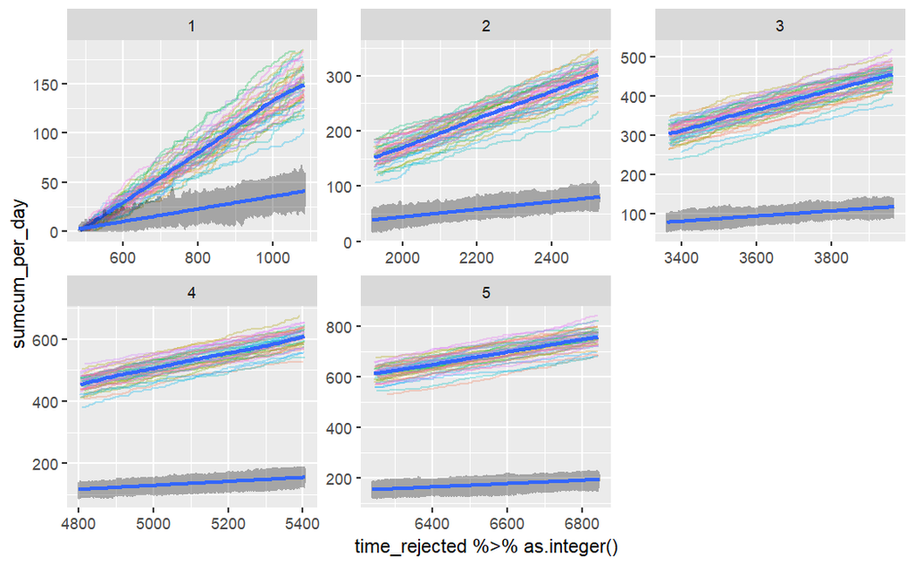

```r
attributes.df1 %>%
  filter(key == "phone_rejected") %>%
  mutate(day = day %>% as_factor(), replication = replication %>% as_factor) %>%
  group_by(replication) %>%
  reframe(time_rejected = pessoa_end_time, sumcum_per_day = cumsum(value), day = day) %>%
  ggplot(aes(x = time_rejected %>% as.integer(), y = sumcum_per_day)) +
  geom_line(aes(color = replication), alpha = 0.3) +
  geom_smooth() +
  facet_wrap(vars(day), scale = "free") +
  theme(legend.position = "none") +
  geom_step(data = resources %>%
              mutate(day = ceiling(time/(24*60))) %>%
              group_by(replication) %>%
              reframe(day = day %>% as_factor(), time = time, queue_size = queue) %>%
              mutate(replication = replication %>% as_factor()),
            aes(x = time, y = queue_size), alpha = 0.3) +
  geom_smooth(data = resources %>%
                mutate(day = ceiling(time/(24*60))) %>%
                group_by(replication) %>%
                reframe(day = day %>% as_factor(), time = time, queue_size = queue) %>%
                mutate(replication = replication %>% as_factor()),
              aes(x = time, y = queue_size), method="lm") +
  facet_wrap(vars(day), scale = "free") +
  theme(legend.position = "none")
```

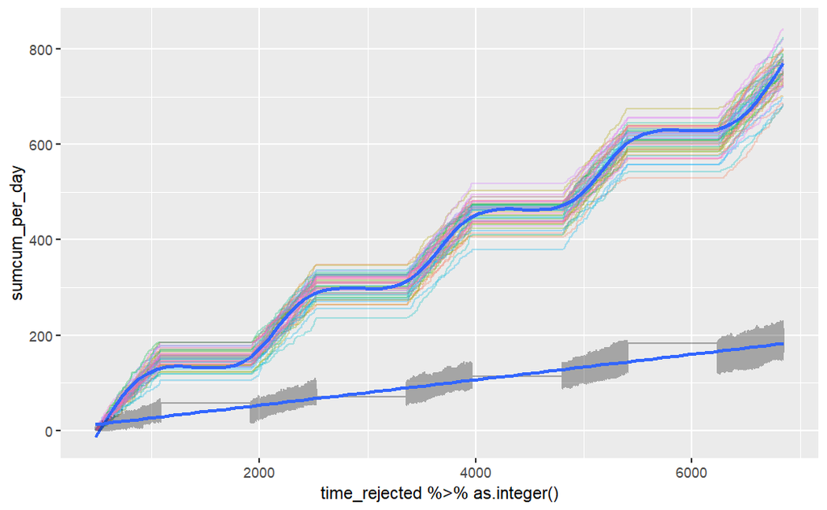

```r
attributes.df1 %>%
  filter(key == "phone_rejected") %>%
  mutate(day = day %>% as_factor(), replication = replication %>% as_factor) %>%
  group_by(replication) %>%
  reframe(time_rejected = pessoa_end_time, sumcum_per_day = cumsum(value), day = day) %>%
  ggplot(aes(x = time_rejected %>% as.integer(), y = sumcum_per_day)) +
  geom_line(aes(color = replication), alpha = 0.3) +
  geom_smooth() +

  theme(legend.position = "none") +
  geom_step(data = resources %>%
              mutate(day = ceiling(time/(24*60))) %>%
              group_by(replication) %>%
              reframe(day = day %>% as_factor(), time = time, queue_size = queue) %>%
              mutate(replication = replication %>% as_factor()),
            aes(x = time, y = queue_size), alpha = 0.3) +
  geom_smooth(data = resources %>%
                mutate(day = ceiling(time/(24*60))) %>%
                group_by(replication) %>%
                reframe(day = day %>% as_factor(), time = time, queue_size = queue) %>%
                mutate(replication = replication %>% as_factor()),
              aes(x = time, y = queue_size), method="lm") +

  theme(legend.position = "none")
```

```r
# tempo de espera daqueles que concluiram, speardao por chamada e mensagem
attributes %>%
  filter(key == "atendido") %>%
  left_join(arrivals.df1 %>% select(start_time, name, replication), join_by("name", "replication")) %>%
  left_join(contactos.df1, join_by("name", "replication")) %>%
  mutate(time_waiting = time - start_time) %>%
  select(name, value, replication, time_waiting, contacto) -> waiting_times
waiting_times
```

| name | value | replication | time_waiting | contacto |
| --- | --- | --- | --- | --- |
| pessoa0 | 1 | 1 | 0.000000e+00 | telefone |
| pessoa1 | 1 | 1 | 0.000000e+00 | telefone |
| pessoa3 | 1 | 1 | 2.575888e+00 | telefone |
| pessoa2 | 1 | 1 | 6.453323e+00 | app |
| pessoa4 | 1 | 1 | 1.368552e+00 | telefone |
| pessoa5 | 1 | 1 | 2.292556e+00 | telefone |
| pessoa7 | 1 | 1 | 4.615478e+00 | telefone |
| pessoa8 | 1 | 1 | 4.585986e+00 | telefone |
| pessoa12 | 1 | 1 | 4.567930e+00 | telefone |
| pessoa13 | 1 | 1 | 3.040728e+00 | telefone |

[output cut: 990 more lines]

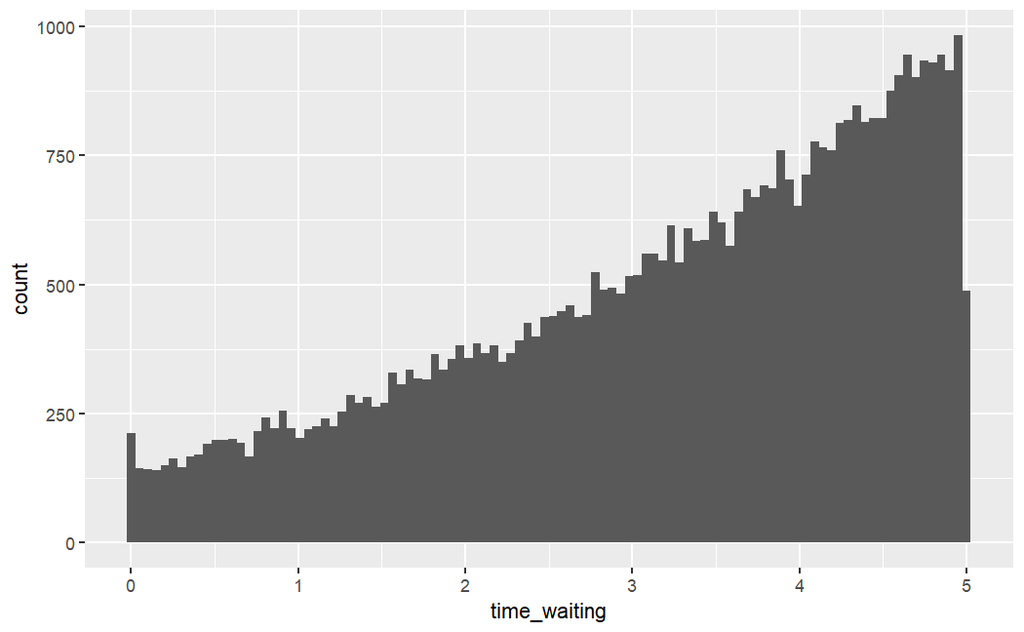

```r
# histograma (n tou a perceber pq é q há waiting times maiores que 5)
waiting_times %>%
  filter(contacto == "telefone") %>%
  ggplot(aes(x = time_waiting)) +
  geom_histogram(bins = 100) +
  theme(legend.position = "none")

ggsave("1.HistTel1repl.svg")
```

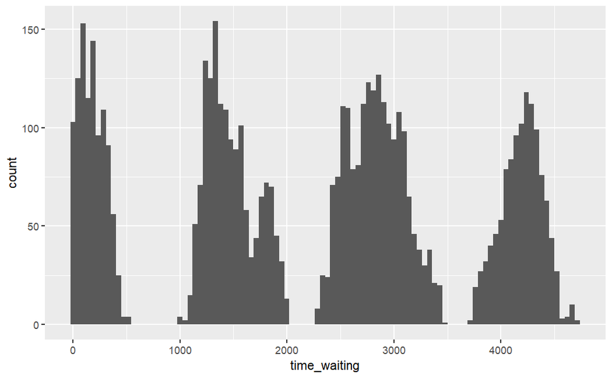

```r
waiting_times %>%
  filter(contacto == "app") %>%
  ggplot(aes(x = time_waiting)) +
  geom_histogram(bins = 100) +
  theme(legend.position = "none")

ggsave("1.HistMen1repl.svg")
```

```r
# regular waiting time stats without graphs
waiting_times %>%
  group_by(contacto) %>%
  summarise(mean = mean(time_waiting), sd = sd(time_waiting), median = median(time_waiting))
```

| contacto | mean | sd | median |
| --- | --- | --- | --- |
| app | 2251.977547 | 1378.724921 | 2512.553944 |
| telefone | 3.224346 | 1.313501 | 3.493646 |

```r
waiting_times %>%
  group_by(contacto) %>%
  summarise(quantile_10 = quantile(time_waiting, 0.1), quantile_20 = quantile(time_waiting, 0.2), quantile_30 = quantile(time_waiting, 0.3), quantile_40 = quantile(time_waiting, 0.4), quantile_50 = quantile(time_waiting, 0.5), quantile_60 = quantile(time_waiting, 0.6), quantile_70 = quantile(time_waiting, 0.7), quantile_80 = quantile(time_waiting, 0.8), quantile_90 = quantile(time_waiting, 0.9), quantile_95 = quantile(time_waiting, 0.95), quantile_99 = quantile(time_waiting, 0.99))
```

| contacto | quantile_10 | quantile_20 | quantile_30 | quantile_40 | quantile_50 | quantile_60 | quantile_70 | quantile_80 | quantile_90 | quantile_95 | quantile_99 |
| --- | --- | --- | --- | --- | --- | --- | --- | --- | --- | --- | --- |
| app | 181.965888 | 1167.787385 | 1378.261397 | 1708.012944 | 2512.553944 | 2774.295466 | 2997.783651 | 3821.707088 | 4215.329170 | 4333.145404 | 4480.204607 |
| telefone | 1.208751 | 1.987473 | 2.592259 | 3.081998 | 3.493646 | 3.859982 | 4.186819 | 4.480079 | 4.747473 | 4.874842 | 4.975484 |

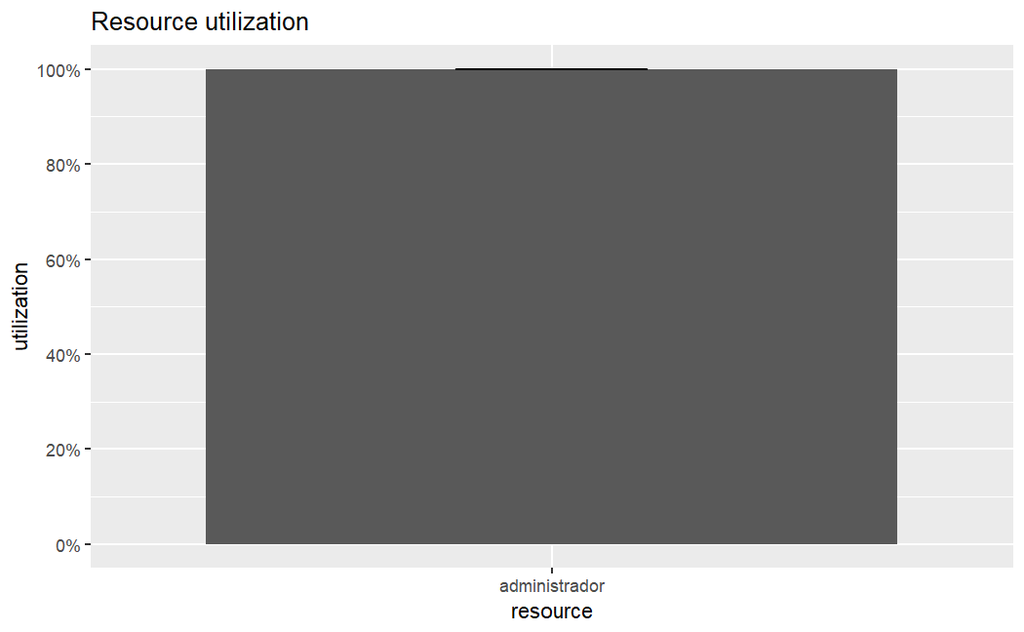

```r
resources %>% plot(metric = "utilization")
```

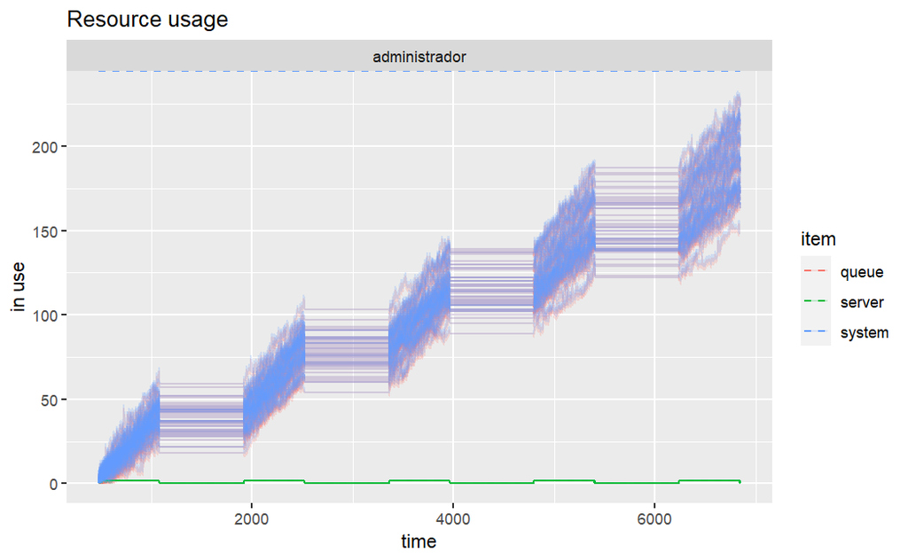

```r
resources %>% plot(metric = "usage", steps = T)
```

## Pergunta 2

Alíneas com mudanças relativas às interrupções

```r
# mudanças
envs <- lapply(1:50, function(i) {
  env <<- simmer("hospital")
  env %>%
    add_generator("pessoa_de_manha", pessoa, from_to(8*60, 10*60, \() rexp(1, (120/2)/60), every = 24*60, arrive = F), mon = 2) %>%
    add_generator("pessoa_de_tarde", pessoa, from_to(10*60, 16*60, \() rexp(1, (240/6)/60), every = 24*60, arrive = F), mon = 2) %>%
    add_generator("pessoa_de_noite", pessoa, from_to(16*60, 18*60, \() rexp(1, (40/2)/60), every = 24*60, arrive = F), mon = 2) %>%
    add_resource("administrador", schedule(
      c(8 , 9 , 9.5 , 12 , 15.5 ,18)*60,
      c(  1 , 2,    4,   3,     1,  0),
      period = 24*60
    )) %>%
    run(24*60*5)
})

envs %>% simmer.plot::get_mon_arrivals(ongoing = T) -> arrivals
envs %>% simmer.plot::get_mon_attributes() -> attributes
envs %>% simmer.plot::get_mon_resources() -> resources
```

```r
# b)
arrivals %>%
  filter(start_time != -1) %>% # n sei pq e q isto acontece
  arrange(start_time) %>%
  select(-activity_time) %>%
  mutate(
    day = ceiling(start_time/(24*60)),
    start_time_day = start_time %% (24*60) %>% seconds_to_period(),
    end_time_day = end_time %% (24*60) %>% seconds_to_period(),
    replication = replication %>% as_factor(),
  ) -> arrivals.df2b
arrivals.df2b %>% filter(replication == 1) %>% mutate(start_time_day = start_time_day %>% round(3), end_time_day = end_time_day %>% round(3))
```

[output not shown]

```r
# tempo de espera daqueles que concluiram, speardao por chamada e mensagem
arrivals.df2b %>%
  filter(finished == TRUE) %>%
  mutate(waiting_time = end_time - start_time) %>%
  left_join(attributes %>% filter(key == "tipo_de_contacto"), by = c("name", "replication")) %>%
  mutate(tipo_de_contacto = ifelse(value == tipo_de_contacto.TELEFONE, "telefone", "mensagem") %>% as_factor, replication = replication %>% as_factor) %>%
  select(name, replication, waiting_time, tipo_de_contacto) -> waiting_times.2b
waiting_times.2b
```

[output not shown]

```r
# a) set_prioritization(\() if (get_attribute(env, "tipo_de_consulta") == tipo_de_consulta.TELEFONICA) c(1, -1, FALSE) else c(0 , -1, FALSE))
pessoa__ <- join(
  pessoa[1:2],
  trajectory("change_prio") %>%
     set_prioritization(\() if (get_attribute(env, "tipo_de_contacto") == tipo_de_contacto.TELEFONE) c(1, 1, FALSE) else c(0 , 0, FALSE)),
  pessoa[-(1:3)]
)
pessoa__
```

[output not shown]

```r
envs <- lapply(1:50, function(i) {
  env <<- simmer("hospital")
  env %>%
    add_generator("pessoa_de_manha", pessoa__, from_to(8*60, 10*60, \() rexp(1, (120/2)/60), every = 24*60, arrive = F), mon = 2) %>%
    add_generator("pessoa_de_tarde", pessoa__, from_to(10*60, 16*60, \() rexp(1, (240/6)/60), every = 24*60, arrive = F), mon = 2) %>%
    add_generator("pessoa_de_noite", pessoa__, from_to(16*60, 18*60, \() rexp(1, (40/2)/60), every = 24*60, arrive = F), mon = 2) %>%
    add_resource("administrador", schedule(
      c(8 , 9 , 9.5 , 12 , 15.5 ,18)*60,
      c(  1 , 2,    4,   3,     1,  0),
      period = 24*60
    )) %>%
    run(24*60*5)
})

envs %>% simmer.plot::get_mon_arrivals(ongoing = T) -> arrivals
envs %>% simmer.plot::get_mon_attributes() -> attributes
envs %>% simmer.plot::get_mon_resources() -> resources
```

```r
arrivals %>%
  filter(start_time != -1) %>% # n sei pq e q isto acontece
  arrange(start_time) %>%
  select(-activity_time) %>%
  mutate(
    day = ceiling(start_time/(24*60)),
    start_time_day = start_time %% (24*60) %>% seconds_to_period(),
    end_time_day = end_time %% (24*60) %>% seconds_to_period(),
    replication = replication %>% as_factor(),
  ) -> arrivals.df2a
arrivals.df2a %>% filter(replication == 1) %>% mutate(start_time_day = start_time_day %>% round(3), end_time_day = end_time_day %>% round(3))
```

[output not shown]

```r
# analise de eficiencia
attributes %>%
  left_join(arrivals.df2a, by = c("name", "replication") ) %>%
  select(name, key, value, replication, day, end_time, end_time_day) -> atributes.df2a
atributes.df2a %>%
  filter(key == "phone_rejected")
```

[output not shown]